# EstimatingPublicationBias

## Methods

### Data extraction

All eight published or in press large scale replication projects performed within in the behavioral science research literature were included in the current research (see table 1 for a list of the the included studies and their sample size determination methods). The original source of each replicated effect, reported test statistics, effect sizes, sample sizes, standard errors and p-values were extracted for each original and replication study. Several of the large scale replication projects did not present the original test statistics and p values (e.g., Many labs 1 and 3 {Klein, 2014 #988;Ebersole, 2016 #985}). In these cases, these values were manually extracted from the original articles. When sample sizes for original studies were not available they were manually extracted from original articles where possible.

For analysis, the original and replication effect sizes were transformed to Fisher z Transformed correlation coefficents following the methods used in {Open Science Collaboration, 2015 #611}. Cases where the the study-level results were not reported in correlation coefficients, Cohen’s d, or when the orignal test result was reported as a t-test or F statistic were excluded from analysis (e.g., when effects were only reported as Cohen’s q or when no effect size was reported). This means that some studies have been left out of the current analysis (e.g., those which used Chi Square tests in {Open Science Collaboration, 2015 #611} and those reported only as Beta coefficents in [loopr citation]). In cases where sample sizes were not reported per group, sample sizes among groups were assumed to be equal in these conversions. See Table 1 for the number of valid studies extracted from each project. See supplementary materials 1 for a comprehensive account of exclusions and study specific extraction details for each replication project. An original and replication effect size that could be converted to a Fisher z score along with sample sizes for original and replication studies was extracted for a total of 303 studies.

Table 1. The reference of each replication project, the number of replication studies performed as a part of each replication project, and the number of studies for which Fisher Z transformed correlation coefficents could be extracted for both the original and replication studies.

| Replication projects | Number of replication studies performed | Reported replication rate (statistically significant results in the same direction) | Included studies | Percent performed replication studies included |
| --- | --- | --- | --- | --- |
| Camerer, C. F., Dreber, A., Forsell, E., Ho, T.-H., Huber, J., Johannesson, M., . . . Wu, H. (2016). Evaluating replicability of laboratory experiments in economics. Science, 351(6280), 1433. DOI: 10.… | 18 | 61% | 18 | 100% |
| Camerer, C. F., Dreber, A., Holzmeister, F., Ho, T.-H., Huber, J., Johannesson, M., . . . Wu, H. (2018). Evaluating the replicability of social science experiments in Nature and Science between 2010 a… | 21 | 62% | 21 | 100% |
| Cova, F., Strickland, B., Abatista, A., Allard, A., Andow, J., Attie, M., . . . Colombo, M. (2018). Estimating the reproducibility of experimental philosophy. Review of Philosophy and Psychology, 1-36… | 37 | 78% | 30 | 81% |
| Ebersole, C. R., Atherton, O. E., Belanger, A. L., Skulborstad, H. M., Allen, J. M., Banks, J. B., . . . Nosek, B. A. (2016). Many Labs 3: Evaluating participant pool quality across the academic semes… | 9 | 33% | 8 | 89% |
| Klein, R. A., Ratliff, K. A., Vianello, M., Adams, R. B., BahnÃk, Å ., Bernstein, M. J., . . . Nosek, B. A. (2014). Investigating Variation in Replicability. Social Psychology, 45(3), 142-152. doi:10… | 16 (13 effects) | 88% (85%) | 15 | 94% (92%) |
| Klein, R. A., Vianello, M., Hasselman, F., Adams, B. G., Adams, R. B., Alper, S., … Nosek, B. A. (2018). Many Labs 2: Investigating Variation in Replicability Across Samples and Settings. Advances In … | 28 | 54% | 22 | 79% |
| Open Science Collaboration. (2015). Estimating the reproducibility of psychological science. Science, 349(6251), aac4716. doi:10.1126/science.aac4716 | 97 | 36% | 89 | 92% |
| Soto et al (2018) $_a$ | 121 | 86% | 100 | 83% |
| All projects | 347 | 65 | 303 | 87% |

Note: $_a$ Soto et al’s (2018)’s replication rate and was recalculated on the “study” (i.e., using the number of replicated effects not the number of trait-outcome associations as is reported in the paper) using results disattenuated using the Spearman-Brown prediction formula and Spearman disattenuation formula (Lord & Novick, 1968) to account for less reliable shorter form measures used in the replication studies. $_b$ Klein et al. (2014) includes 4 operationalisations of a single effect which were input seperatly for analysis in the current study, the bracketed values in the table refer to the number of results at the effect level.

### Analysis

This paper uses four analytic techniques to examine the change in effect sizes from original to replication studies. All analysis was performed in R version 3.5.1 {R Development Core Team, 2018 #314} and meta-analyses were performed using the Metafor package {Viechtbauer, 2010 #796}. All analyses and difference scores (i.e., proportion changes and mean differences) were calculated using Fisher Z transformed effect sizes, and effect sizes are back transformed to correlation coefficents for easy interpretation unless otherwise stated. All analyses were exploratory, and multiple models which were developed are not presented here. See https://github.com/fsingletonthorn/effectSizeAdjustment for a git repository with a record of all interim models and for all model code and data, and see https://osf.io/daj8b for the preregistration of this project specifying that all analyses would be exploratory.

##### Analysis 1: Multilevel random effects meta-analysis

The first approach uses a random effects meta-analysis framework to estimate the expected effect size decrease between original and replication studies.

$differnce_{ij} = \beta_0 + \eta_{id} + \eta_{article} + \eta_{project} + \epsilon_{ij}$

This analysis treats each pair of effects, the original and replicated sample size, as one “study” in a meta-analytic framework, and estiamtes the change from original to replication study ($differnce_{ij}$). In order to account for non-independence between the included difference scores, random effects for replication project ($\eta_{project}$ and original article ($\eta_{article}$) are included (as in some cases, multiple effects from an original article were replicated or multiple operationalisations of an original effect were tested), and random effects are also included for each individual effect ($\eta_{id}$). Standard errors for each difference score were estimated as $se = \sqrt{\frac{1}{N_{1} -3} + \frac{1}{N_{2} -3} }$, with $N_1$ being the sample size in the original study and $N_2$ being the sample size in the replication study. Empirical Bayes estimates and 95% credible intervals for random effects are also calculated following {Robinson, 1991 #999}{Morris, 1983 #1000}.

#### Accounting for null results

An important question in assessing the degree to which effects are attenuated in this literature is how much this effect is driven by the presence of a subset of null effects (or effects so small as to be effectively null). The average attenuation could be extremely high, and yet this effect be almost entirely driven by the presence of effectively-null effects. In order to account for this issue, three main methods are used.

##### Analysis 2: Multilevel random effects meta-analysis with exclusions

The first method is to re-perform the meta-analysis excluding studies using two exclusion criteria; excluding studies in which the replication study was not significant and removing statistically equivalent studies. Because both of these methods function by removing small replication effects, no significance testing was performed on the difference between the model estimates estimated decreases after accounting for small or near-null effects. It is certain that, at a population level, both of these exclusion rules would lower the size of the observed effect size decrease.

Our first exclusion method excludes effects where the replicaiton studies did not reach statistical significance or which had significant results in the opposite direction to the origianl effect. Problematically, this means that replication studies which have a low level of staistical power to detect the true effect size under study are likely to be excluded. Especially as in some of the replication projects the sample size in the replication study was chosen using a power analysis of the observed effect in the original study {Open Science Collaboration, 2015 #611}, this method is likely to underestimate the amount of effect size exaggeration due to the exclusion of under-powered replications.

In order to avoid excluding under-powered studies erroneously, we also excluded studies based on whether the results of the replication study were statistically equivalent to the null {Lakens, 2017 #214;Lakens, 2018 #951}, or significant in the opposite direction. As a requirement for equivalence testing is that a minimum effect size of interest is selected, we follow one suggestion in {Lakens, 2018 #951} and use the lowest effect size that would be statistically significant to the original study as the smallest effect of interest (assuming an alpha of .05). Equivalence tests were performed used the Fisher Z transformed effect sizes, and approximated the standard errors of each study as $\sqrt{\frac{1}{n-3}}$, except for studies from {Camerer, 2018 #967} which had more than a single replication attempts, where standard errors are those derived from the meta-analyses that produced the effect size estimate. Equivalence tests were performed using Z tests of the Fisher Z transformed correlation coefficients.

In interpreting results based on this exclusion criteria, it is important to note that the minimum detectable effect was occasionally quite high as original sample sizes were often very small (mean equivilence bound = 0.18, SD = 0.12, 0th, 25th, 50th, 75th and 100th quintiles = [0, 0.1, 0.15, 0.24, 0.74]). This means that original studies were sometimes under-powered to detect even large effects using the current analysis, and that this method may exclude studies which have effects the original authors may have considered important, but which would not have reached statistical significance in the original study. See supplementary materials 2 for scatter plots of the data-set using each exclusion rule.

##### Analyis 3: Mixed effects meta regression

The second method of estimating the expected effect size decrease assuming a non-null alternative hypothesis uses the same meta-analytic model as above but adds the replication p value as a moderator.

$differnce_{ij} = \beta_0 +\beta_1Pvalue + \eta_{id} + \eta_{article} + \eta_{project} + \epsilon_{ij}$

This model acts as a convinient method of allowing the model to fit the effect size decreases in cases in which the effect in the replicaiton study did not produce low p values, p values more likely under the alternative than null hypothesis, making $\beta_0$ an estimate of the difference between original and replication effects given a replication p value of 0. This appraoch is limited as the distribution of p values is uniform under the null hypothesis, and as the probability of obtaining low p values under the alternative hypothesis is determined by the (unknowable) statistical power of the replication study.

### Descriptives

#### Raw changes in effect sizes

Looking at the 303 replications for which both original and replication effect sizes were available, the effect size seen in the replication study was lower than that seen in the original study in 216 articles, 71% of the included articles. The average effect size for original studies was 0.39, and the mean effect size for replication studies was 0.27. There was an average decrease of r = -0.13. Notably, this represents an average decrease in effect sizes from the original to the replication study of 28%. See Table 2 for a comprehensive list of descriptives on the effect size differences seen, Figure 1 for a scatterplot of the replication effect sizes plotted against the original studies’ and Figure 2 for a raincloud plot of the Fisher Z score change in effect sizes by replication project.

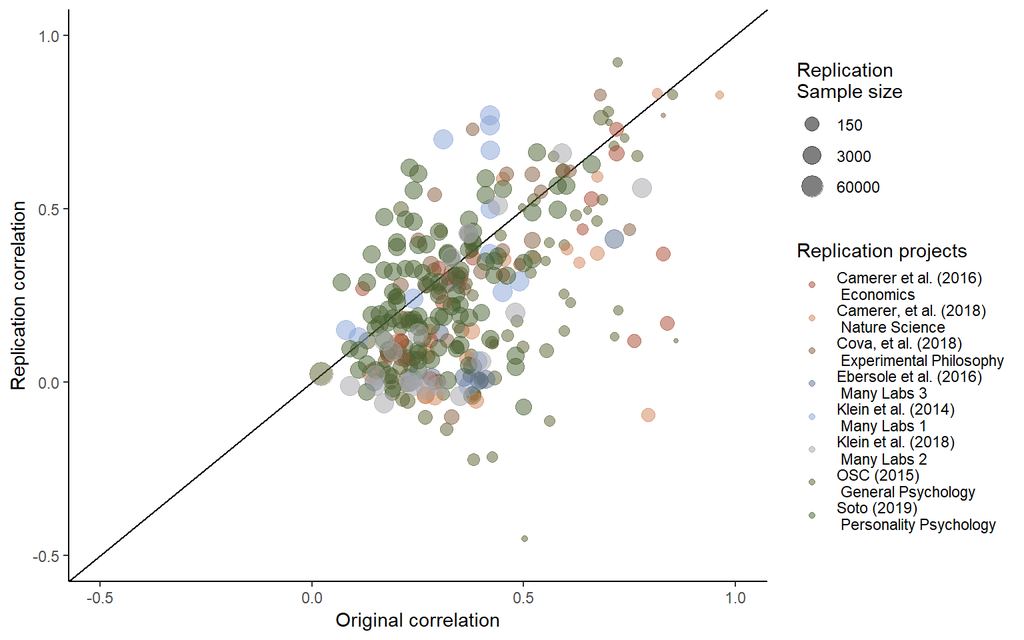

Figure 1. A scatterplot of replication study effect sizes (in correlation coefficients) plotted against original study effect sizes. Points which fall on the the solid, diagonal line represent replication effect sizes equal to the original effect sizes. Point size represents (the log) of the number of participants in the replication study, and the color of the points shows which replication project each effect size pair was from.

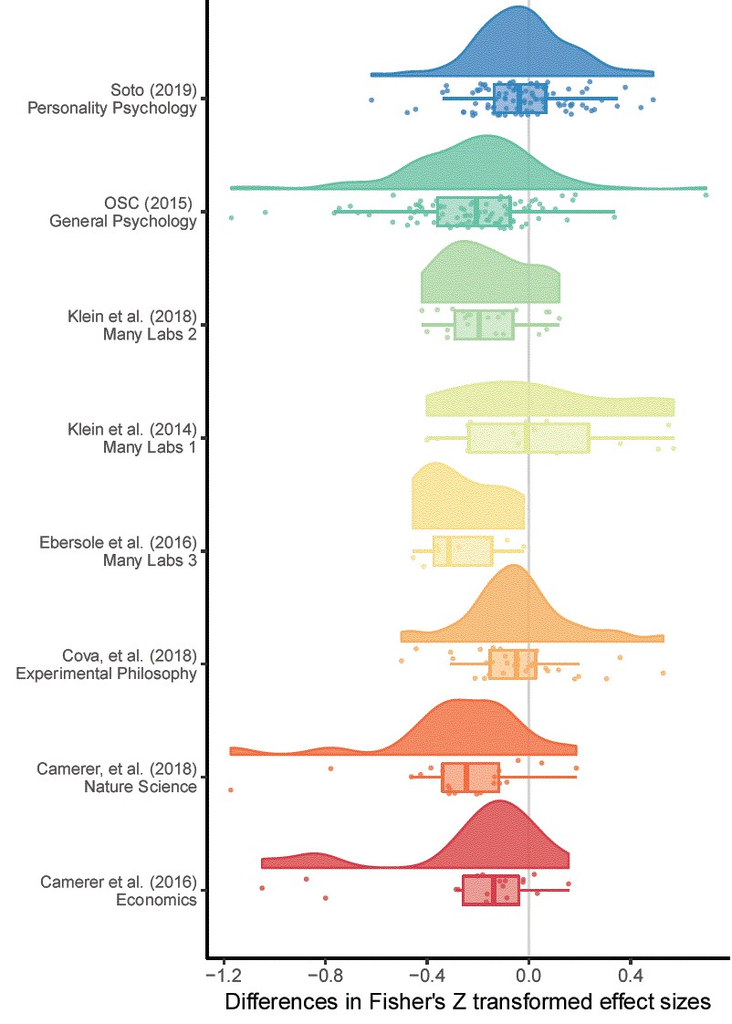

Figure 2. A raincloud plot of the change in effect sizes (here Fisher Z scores) from the original to the replication study by the replication project that each replication study was performed as a part of.

##### Descriptives of samples after exclusions

Examining the 195 replications in which the replication study was statistically significant, 64% of all studies, the average effect for original studies was 0.41, and the mean effect size for replication studies was 0.39. There was an average decrease of r = -0.02, a mean percentage increase in effect sizes of 5% and a median decrease of 7%.

Using equivalence testing, a total of 234 studies were not statistically equivalent to the null, 77% of included studies. The average effect size in the original non-equivalent studies was 0.41, compared to a mean effect size for replication studies of r = 0.35. This is a mean decrease of r = -0.07, a mean percentage decrease of 7%, and a median decrease of 16%..

Table 2. Differences between original and replication studies. All calculations were performed on Fisher’s Z transformed correlations and presentened effect sizes are back-transformed into correlation coefficients for interpretability.

|  | n included | Mean original ES | Median original ES | Mean replication ES | Median replicaiton ES | Mean ES difference | Median ES difference | SD difference | Mean proportion change | Median proportion change |
| --- | --- | --- | --- | --- | --- | --- | --- | --- | --- | --- |
| Overall | 303 | 0.39 | 0.33 | 0.27 | 0.22 | -0.13 | -0.11 | 0.25 | -0.28 | -0.34 |
| StatisticalSignificance | 195 | 0.41 | 0.35 | 0.39 | 0.34 | -0.02 | -0.03 | 0.20 | 0.05 | -0.07 |
| Nonequivalence | 234 | 0.41 | 0.35 | 0.35 | 0.30 | -0.07 | -0.06 | 0.24 | -0.07 | -0.16 |

### Results

#### Analysis 1: Multilevel random effects meta-analysis results

The mutlilevel random effects meta-analysis including all data estimates a r = -0.14 (95% CI [-0.2, -0.07]) decrease in effect sizes from the original to replication studies. This represents a decrease equivalent to 34% (95% CI [51%, 17%]) of the mean effect size in the original studies (a Fisher Z transformed correlation coefficent equivliant to a correlation coefficent of 0.37).

Table [nice mod sum]. Model output from a multilevel random effects meta-analysis of the difference between original and replication effect sizes, with random effects for the project (i.e., which large scale replication project the replication was a part of) and the original (i.e., replicated) article or effect.

| Estimate | 95% CI LB | 95% CI UB | SE | p | Random effects |
| --- | --- | --- | --- | --- | --- |
| -0.137 | -0.207 | -0.068 | 0.035 | < .001 |  |
|  |  |  |  |  | Project variance = 0.008, n = 8 |
|  |  |  |  |  | Article variance = 0.017, n = 226 |
|  |  |  |  |  | Effect variance = 0.017, n = 303 |
|  |  |  |  |  | QE(302) = 3525.8, p < .001 |

Table [BLUP]. Empirical Bayes estimates and 95% credible intervals for random effects (i.e., estiamtes of the difference between the replication project’s mean effect size difference and the overall estimated mean effect size difference). These values are equivalent to 95% confidence intervals assuming that the studies are a random sample from a population with normally distributed average effect size difference.

|  | Estimate | Standard Error | 95% PI lower bound | 95% PI upper bound |
| --- | --- | --- | --- | --- |
| Camerer et al. (2016) Economics | -0.060 | 0.052 | -0.161 | 0.042 |
| Camerer, et al. (2018) Nature Science | -0.075 | 0.052 | -0.178 | 0.027 |
| Cova, et al. (2018) Experimental Philosophy | 0.081 | 0.047 | -0.011 | 0.174 |
| Ebersole et al. (2016) Many Labs 3 | -0.065 | 0.060 | -0.182 | 0.053 |
| Klein et al. (2014) Many Labs 1 | 0.117 | 0.054 | 0.011 | 0.223 |
| Klein et al. (2018) Many Labs 2 | -0.025 | 0.048 | -0.119 | 0.069 |
| OSC (2015) General Psychology | -0.051 | 0.041 | -0.132 | 0.030 |
| Soto (2019) Personality Psychology | 0.078 | 0.042 | -0.005 | 0.160 |

#### Analysis 2: Multilevel random effects meta-analysis with exclusions results

It is important to emphasize the degree of uncertainty in these results. These values represent changes equivalent to a decrease of -12 to -20% of the average original effect size (a correlation coefficent of r = 0.39). Looking at the range of the 95% confidence intervals for both of these subsamples, the coverage extends from a considerable decrease equivalent to -38% of the average original correlation, to a samll increase in effect sizes equivalent to 3% of the average original effect size.

##### Table [all model output]

The number of studies included in each model, and the estimated correlation coefficient decrease from each model. Models were estimated using Fisher Z transformed correlation coefficients and back transformed for interpretability. Percentage attenuation gives the percentage attenuation for effect size differences as a percentage of the the mean original effect size (r = 0.37).

| Inclusion rule | Model N | Model Estimate | 95% CI lb | 95% CI ub | Estimated % attenuation | LB % attenuation | UB % attenuation |
| --- | --- | --- | --- | --- | --- | --- | --- |
| All studies | 303 | -0.14 | -0.20 | -0.07 | -34 | -51 | -16.6 |
| Statistically significant | 195 | -0.05 | -0.11 | 0.01 | -12 | -27 | 3.3 |
| Non-equivalent | 234 | -0.08 | -0.15 | -0.01 | -20 | -38 | -1.8 |

#### Analysis 3: Including replication p values as a moderator in a mixed effects meta-analysis

This analysis leads to similar conclusions to the models with exclusions, with an estimated effect size decease of r = -0.08, 95% CI [-0.14, -0.02]. This represents a decrease of -19% (95% CI [-34%, -5%]) of the average original effect size. The projects and article level variances are functionally identical to the model that does not include replication p values as a moderator.

Table [moderators]. Multilevel meta-regression results including the p value of the replication study as a moderator.

|  | Estimate | 95% CI LB | 95% CI UB | SE | p | Random effects |
| --- | --- | --- | --- | --- | --- | --- |
| Estimate | -0.078 | -0.14 | -0.019 | 0.030 | 0.009 |  |
| p value | -0.340 | -0.43 | -0.244 | 0.049 | < .001 |  |
|  |  |  |  |  |  | Project variance = 0.005, n = 8 |
|  |  |  |  |  |  | Article variance = 0.014, n = 226 |
|  |  |  |  |  |  | Effect variance = 0.014, n = 303 |
|  |  |  |  |  |  | QE(302) = 3143.71, p < .001 |

##### Leave one out cross validation of meta-analyses

To assess how sensitive the results of the multilevel models are to the inclusion of each of the replication projects, the included studies, and the individual replicated effects, all of the above mulitilevel models were rerun using leave one out cross validation, excluding both each effect, effects from each origianal study (i.e., in cases where multiple effects were tested from the same original source), and each replication project one at a time. None of these analyses led to model estimates (i.e., the expected decrease in effect size between origianl and replication study or equivalently the intercept estimate) that were further than 0.02 from those given above, suggesting that none of the individual projects, effects or studies included were overly influential. See supplementary material [LOO] for a table of the proportion of model intercept p values below .05, and estimate quintiles for each model from the leave on out cross validation on the study and project levels.

#### Analysis 4: Bayesian mixture model results

The Bayesian mixture model was estimated using four Markov chains from each of which 100,000 draws were taken (excluding a 11,000 draw burn-in period). Trace and density plots for the discussed parameters were assessed and the model appeared to have successfully converged. The overall posterior assignment rate (i.e., the proportion of studies which are estimated to be from the non-null alternative hypothesis) is 89%, with a 95% highest probability density interval of [79%, 98%]. The overall attenuation factor (i.e., the estiamted amount that effect sizes decreases between the original and replication studies) is 19% with a 95% highest probability density interval of [11%, 28%]. Figure [mixture model], shows the original effect sizes plotted against replication effect sizes weighted by sample size, along with the posterior assignment rate. The color of each point indicates the proportion of times each effect was assigned to the alternative hypothesis. As was seen and pointed out in the first use of this model in {Camerer, 2018 #967}, values close to the diagonal are reliably assigned to the alternative hypothesis whereas effects far below the diagonal are more often assigned to the null hypothesis, although the overall posterior assignment rate might be overly optimistic (i.e., assign studies to the non-null hypothesis at a high rate). In part, this optimism may be due to the fact that this model allows for true effect sizes to be estimated as being extremely low or near zero and still assigned to the alternative hypothesis not the null, with 29% of the estimated true replication effect sizes being smaller than a correlation coefficient of .1.

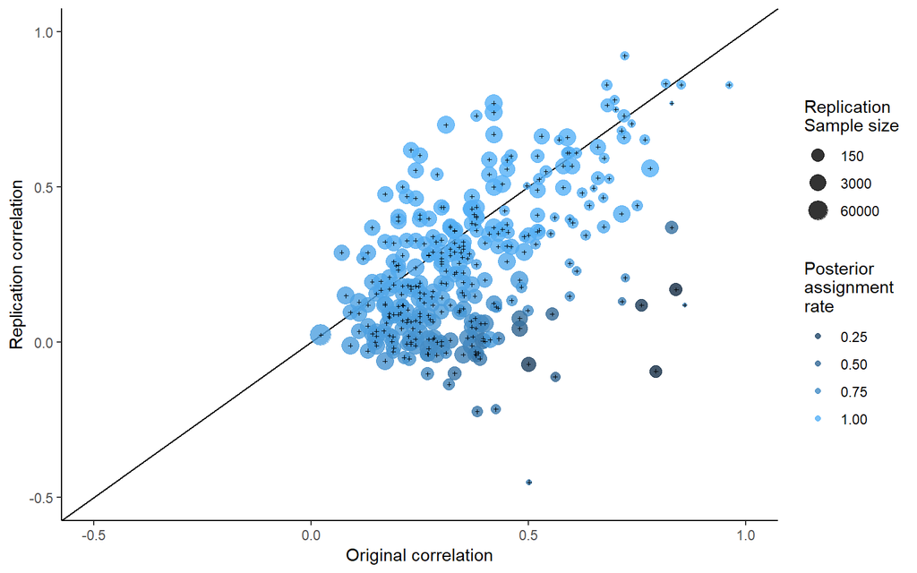

###### Figure [mixture model].

A scatterplot of replication study effect sizes (in correlation coefficients) plotted against original study effect sizes, colored by the posterior assignment rate, the proportion of times each study was assigned to the alternative hypothesis. Points which fall on the the solid, diagonal line represent replication effect sizes equal to the original effect sizes. Point size represents (the log) of the number of participants in the replication study.

## Discussion

Arguably of more interest to researchers examining and planning research is the question of the degree of effect size attenuation expected under the assumption that the effect size is non-zero. All of the methods used here largely agree, although the degree of precision differs. The results of the two methods used to formally model this provide similar but more precise estimates, both estimating a decrease of approximately 20%, with a 95% highest probability density interval for the mixture model of a 95% highest probability density interval of [-28%, -11%] and a 95% confidence interval for the multilevel model including replication p Values as a moderator of [-34%, -5%]) of the average original effect size.

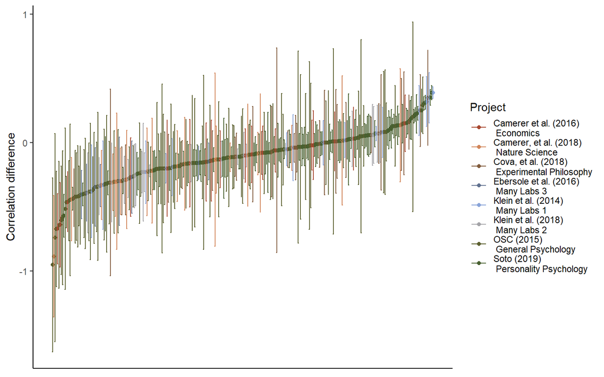

Figure x. A caterpillar plot of the effect size difference between original and replication study effect sizes ordered by magnitude, error bars are 95% confidence intervals around effect size differences.

#### Limitiations and future directions

None of the projects included in this analysis were true random selections from the literature, and it is possible that the pattern in the selected sample may be different that that which would be seen in the literature overall. Additionally, although a number of different approaches were used to estimate the amount of effect size, all of the methods that were used to exclude replication studies from the multilevel modes which were bound to decrease the amount of effect size decrease that is seen. However, this preliminary analysis does provide suggestive evidence that the degree of effect size attenuation that is seen may be partially attributed to the presence of effectively-null results, and that the overall decrease in effect sizes in non-null studies is still considerable. The current study also does not attempt to distinguish between effect size heterogeneity (i.e., effect sizes that are different under different experimental conditions) and effect size attenuation. However, it seems reasonable to except in that effect size heterogeneity should lead to symmetrical effect size differences, and in so far as it might be expected to be negatively biased in replication studies, this could reasonably be termed effect size attenuation for the purposes of researchers hoping to replicate or plan future similar studies of the same same type of effects.

Furthermore, although the two alternative methods of estimating the amount of effect size reduction seen in non-null models (i.e., the model including replication p values as a moderator and the Bayesian mixture model) provide convergent evidence supporting the estimated effect size decrease assuming a non-null effect, both have issues. The model including p values as a moderator is best considered a heuristic guide, and is not straightforwardly interpretable (i.e., the model provides an estimate of the expected effect size difference given a replication p value of 0, an impossibility, and really acts as a convenience method for adjusting for the probability of the data being observed under the null model in the replication study). The Bayesian mixture model used here has two major issues. Firstly, it assumes independence between effect and that there is a uniform attenuation factor across all areas of psychological research. Secondly, the modeled true effect size can be negligible or even negative and the replication effect size still assumed to be sampled from the alternative distribution not the null. This later issue occurs because the model estimates the relationship between original and replication effect sizes using a two step errors-in-variables approach following {Matzke, 2017 #1012}. Likely in large part due to this second issue, the model estimates the number of false positives at an extremely low rate (11.44% in contrast to other estimates of the number of false positive in this sample, which suggest a false positive rate of approximately 25%). For descriptive and interpretative purposes, this model does have a major benefit in that it estimates a single overall attenuation rate for non-null studies, the main goal of the current article. However, an important task in developing a more nuanced understanding of the data-generation process that leads to this data-set would be building a model that allows for the attenuation rate to change across replication studies, and possibly to allow it to include more components allowing for studies with negligible or negative but non-null effects in addition to the true alternative and null components modeled in the current studies.

### Conclusion

This project emphasizes the importance of efforts to reduce publication and reporting biases. In many cases pre-registration with a sufficiently detailed analytic strategy may help to combat reporting bias by making it easier for researchers to avoid engaging in questionable research practices {Wicherts, 2016 #475}. In exploratory data analysis where an analytic strategy ends up being data-informed (e.g., like the current study), it is important to actively acknowledge this fact and to take other measures to reassure readers that the effects are not a product of a particular analytic strategy or due to other questionable research practices. One possible approach to this issue is to consider and report alternative analytic strategies without regard to whether their outcomes support a given theoretical position or empirical finding. Projects like registered reports, in which papers are reviewed before data-collection based on the design and analysis strategy as opposed to the results also show promise in developing a body of literature which is less effected by reporting and publication bias {Nosek, 2014 #202}.

## SM1

### Replication project Extraction and exclusion details

##### {Camerer, 2018 #967}

Original and replication effect sizes were extracted for all 21 studies included in {Camerer, 2018 #967}. In some cases in the Nature Science reproducibility projects {Camerer, 2018 #967} multiple replication studies were performed for a single effect. In each of these cases we performed a fixed effects meta-analysis using the metafor package {Viechtbauer, 2010 #796} to estimate a meta-analytic effect size estimate. The effect size, standard errors and sample sizes used in the current study reflect this pooled estimate. This method leads to one study more “replicating” according to the ‘statistical significance in the same direction of the original study’ criterion than was originally reported in {Camerer, 2018 #967}, where they used the p value from the largest performed study instead of a pooled estimate.

##### {LOOPR}

Effect sizes were extracted for original and replication studies for 101 out of 121 included studies, and one original study’s sample size was not avaliable. In [LOOPR study CITATION] Effect sizes which were only reported in this dataset as beta coefficients were not converted to Fisher z scores as not enough information was avaliable in the data set. A total of 100 of 121 effects were included in the current analysis. As some replication studies used shorter form versions of the original data collection instruments, all results presented have been disattenuated using the Spearman-Brown prediction formula and Spearman disattenuation formula to estimate the trait-outcome associations that would be expected if our outcome measure had used the same number of items as the original study (Lord & Novick, 1968). Following the other large scale replication studies, the signs of the original and replication study effects were switched if the original effect was negative.

##### Many labs 1 {Klein, 2014 #988}

Many labs 1 {Klein, 2014 #988} examined whether effects from 13 original papers replicated, one of which did not report an effect size or test statistic so is not included in the current sample. No effect size was extractable for one original study, and this effect was excluded for the purposes of the current anlaysis. Four different operationalisations of anchoring effects were tested, all of which are included in the current analysis, leading to a total of 15 paired data-points being included from this study. The multilevel models reported below accounts for non-independence between effects by including a random effect for study.

##### Many labs 2 {Klein, 2018 #1021}

A total of 22 of 28 original and replication effects sizes were extracted for this analysis. Four studies from {Klein, 2018 #1021} were removed because the original and replication studies examined a difference in effect sizes seen in different conditions, and the effects were not directly tested against each other making it difficult to derrive an appropriate effect size. Two additional studies were excluded because their effect sizes were only available as Cohen’s q.

##### {Camerer, 2016 #983}

The economics replication project {Camerer, 2016 #983}. Original and replication effect sizes for all 18 studies were reported in correlation coefficents and all are included in this analysis.

### SM2

### Plots and multilevel model output of the relationship between original and replication correlation coefficents using varied exclusion criteria

The following output shows scatter plots and model output for all of the multilevel meta-analyses performed using the varied exclusion criteria explained in the main text.

Table SM 1. Multilevel meta-analysis model estimates and random effects for all data.

| Estimate | 95% CI LB | 95% CI UB | SE | p | Random effects |
| --- | --- | --- | --- | --- | --- |
| -0.14 | -0.21 | -0.07 | 0.04 | < .001 |  |
|  |  |  |  |  | Project variance = 0.008, n = 8 |
|  |  |  |  |  | Article variance = 0.017, n = 226 |
|  |  |  |  |  | Effect variance = 0.017, n = 303 |
|  |  |  |  |  | QE(302) = 3525.8, p < .001 |

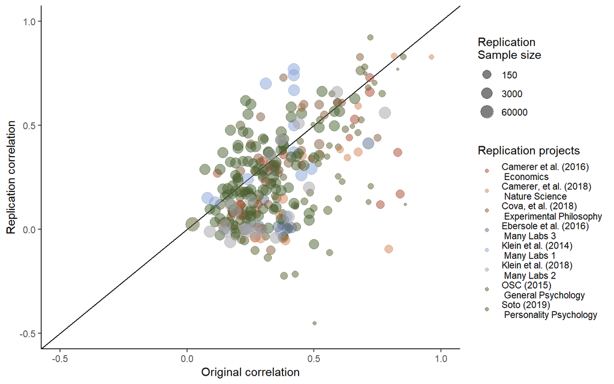

Figure SM1. Scatter plot of replication effect sizes (in correlation coefficients) plotted against original effects including all data.

Table SM2. Multilevel meta-analysis model estimates and random effects including only statistically significant replications.

| Estimate | 95% CI LB | 95% CI UB | SE | p | Random effects |
| --- | --- | --- | --- | --- | --- |
| -0.05 | -0.11 | 0.01 | 0.03 | 0.12 |  |
|  |  |  |  |  | Project variance = 0.005, n = 8 |
|  |  |  |  |  | Article variance = 0.014, n = 129 |
|  |  |  |  |  | Effect variance = 0.014, n = 195 |
|  |  |  |  |  | QE(194) = 2706.56, p < .001 |

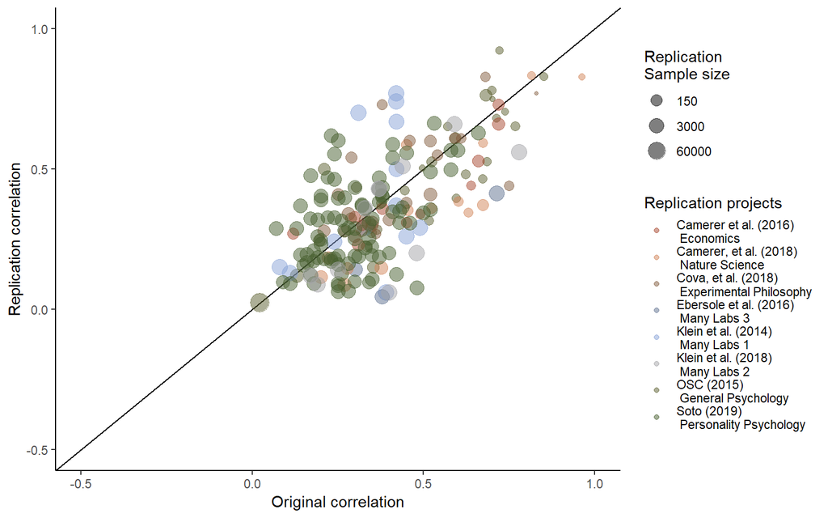

Figure SM2. Scatter plot of replication effect sizes (in correlation coefficients) plotted against original effects including only statistically significant replications.

Table SM3. Multilevel meta-analysis model estimates and random effects including studies which are not statistically equivalent to the null, using equivalence bounds set as the minimum effect size that would have been statistically significant in the original study.

| Estimate | 95% CI LB | 95% CI UB | SE | p | Random effects |
| --- | --- | --- | --- | --- | --- |
| -0.08 | -0.16 | -0.01 | 0.04 | 0.03 |  |
|  |  |  |  |  | Project variance = 0.008, n = 8 |
|  |  |  |  |  | Article variance = 0.018, n = 166 |
|  |  |  |  |  | Effect variance = 0.018, n = 234 |
|  |  |  |  |  | QE(233) = 3023.8, p < .001 |

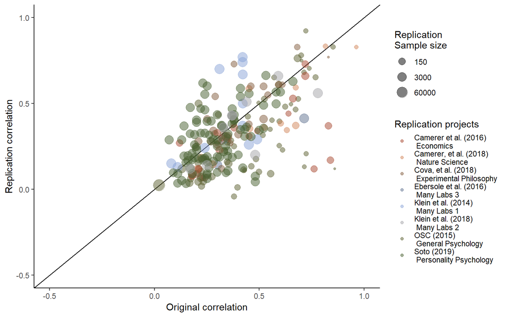

Figure SM3. Scatter plot of replication effect sizes (in correlation coefficients) plotted against original effects including studies which are not statistically equivalent to the null, using equivalence bounds set as the minimum effect size that would have been statistically significant in the original study.

### SM3

### LOO Cross validation output

#### Table LOO cross validation output.

0th, 25th, 50th, 75th and 100th percentiles from leave one out cross validation for each multilevel model, for each exclusion method an, including only the sample indicated in “LOO exclusions”.

| LOO exclusions | Subsample | Proportion significant | Minimum estimate | 25th percentile | Median | 75th percentile | Maximum estimate |
| --- | --- | --- | --- | --- | --- | --- | --- |
| Replication project | Only non-equivalent replications | 0.38 | -0.10 | -0.09 | -0.08 | -0.07 | -0.06 |
| Replication project | Only significant replications | 0.12 | -0.07 | -0.06 | -0.05 | -0.04 | -0.03 |
| Replication project | P value as Moderator | 1.00 | -0.10 | -0.09 | -0.07 | -0.07 | -0.06 |
| Replication project | All data | 1.00 | -0.16 | -0.15 | -0.13 | -0.13 | -0.12 |
| Study | All data | 1.00 | -0.14 | -0.14 | -0.14 | -0.14 | -0.13 |
| Study | Only significant replications | 0.00 | -0.05 | -0.05 | -0.05 | -0.05 | -0.04 |
| Study | Only non-equivalent replications | 0.99 | -0.09 | -0.08 | -0.08 | -0.08 | -0.07 |
| Study | P value as Moderator | 1.00 | -0.09 | -0.08 | -0.08 | -0.08 | -0.07 |
| Effect | Only significant replications | 0.00 | -0.05 | -0.05 | -0.05 | -0.05 | -0.04 |
| Effect | Only non-equivalent replications | 0.99 | -0.09 | -0.08 | -0.08 | -0.08 | -0.07 |
| Effect | P value as Moderator | 1.00 | -0.09 | -0.08 | -0.08 | -0.08 | -0.07 |
| Effect | All data | 1.00 | -0.14 | -0.14 | -0.14 | -0.14 | -0.13 |

### SM4

### Bayesian Mixture Model

The mixture model results presented in text presents the model developed by Camerer et al,. (2018; see https://osf.io/xhj4d/ for their detailed description of this model). All priors were chosen to be uninformative or vague. The mixture model assumes that the observed replication effect sizes either come from the null hypothesis, a true effect sampled from a normal distribution with a mean of zero and a estimated precision (tau). This model uses an errors-in-variables approach to account for possible attenuation of effect sizes due to measurement error and estimation uncertainty following {Matzke, 2017 #1012}, which means the effect size attenuation factor is the factor change between the estimated true effect of the original and replication study effect size. Although this may be reasonable in that the true effect size of the effect may not be the true effect size of a particular study and analysis set up, this poses an interpretative problem in that alpha now represents the difference between the estimated original effect and the replication effect.

Box SM1. The original model reported in {Camerer, 2018 #967} and reported on in the main text of the current article.

```
model{
# Mixture Model Priors:
alpha ~ dunif(0,1) # flat prior on slope for predicted effect size under H1
tau ~ dgamma(0.001,0.001) # vague prior on study precision
phi ~ dbeta(1, 1) # flat prior on the true effect rate
# prior on true effect size of original studies:
for (i in 1:n){
trueOrgEffect[i] ~ dnorm(0, 1)
}
# Mixture Model Likelihood:
for(i in 1:n){
clust[i] ~ dbern(phi)
# extract errors in variables (FT stands for Fisher-transformed):
orgEffect_FT[i] ~ dnorm(trueOrgEffect[i], orgTau[i])
repEffect_FT[i] ~ dnorm(trueRepEffect[i], repTau[i])
trueRepEffect[i] ~ dnorm(mu[i], tau)
# if clust[i] = 0 then H0 is true; if clust[i] = 1 then H1 is true and
# the replication effect is a function of the original effect:
mu[i] <- alpha * trueOrgEffect[i] * equals(clust[i], 1)
# when clust[i] = 0, then mu[i] = 0;
# when clust[i] = 1, then mu[i] = alpha * trueOrgEffect[i]
  }
}
```